# Accountability and Information 1

Final Project Essentials: Fixed Effects

Carolina Torreblanca

University of Pennsylvania

**Global Development**: Intermediate Topics in Politics, Policy, and Data

PSCI 3200 - Spring 2026

# Logistics

## Assignments

- Today
  - Dunning et al. (2019)
  - Data Assignment 1 (due by midnight)
- Tuesday (3/28)
  - Foreign aid readings
  - Github tutorial (maybe)
- April 9
  - Final project proposal

## Agenda

1. Dunning et al. (2019)
2. **FINAL** questions about Data Assignment 1
3. Final Project Essentials: Fixed Effects

# Dunning et al. (2019)

## Barriers hindering accumulation

**What is accumulation?**

- Building knowledge across studies

**What makes it difficult?**

- Limited replication
- Heterogeneity of design and measurement
- Publication bias

## Barriers hindering accumulation

[figure not shown]

## Facilitating accumulation

**What solutions are discussed by the authors?**

- Pre-registration
- Harmonizing theory, measurement, and estimation
- Publication of null results

## Facilitating accumulation

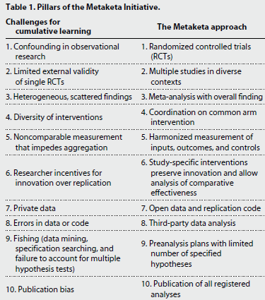

## Models of political accountability

**Accountability requires that voters:**

- Observe credible signal of performance
  - Attribution
  - Benchmarking
- Update their beliefs
- Have credible alternatives

## Models of political accountability

**What does the literature say?**

- Theory is mixed
  - Partisan and sectarian attachments are strong
  - Voters may be reluctant to update their beliefs
- Experimental results are mixed
  - Demobilization
  - Limited recall
  - Ephemeral effects

## Research Design

**Intervention**

- Information on political *performance*
  - Legislative behavior
  - Spending irregularities
  - Budget allocation
  - Candidate experience

## Research Design

**Accountability requires that voters:**

- Observe credible signal of performance
  - Attribution
  - Benchmarking
- Update their beliefs
  - Good news: $Q > P \mid 1(P = Q, Q > med(Q) )$
- Have credible alternatives

## Ecological Validity

- How is information disseminated?
- What is the real world activity being tested?

## Describing Information

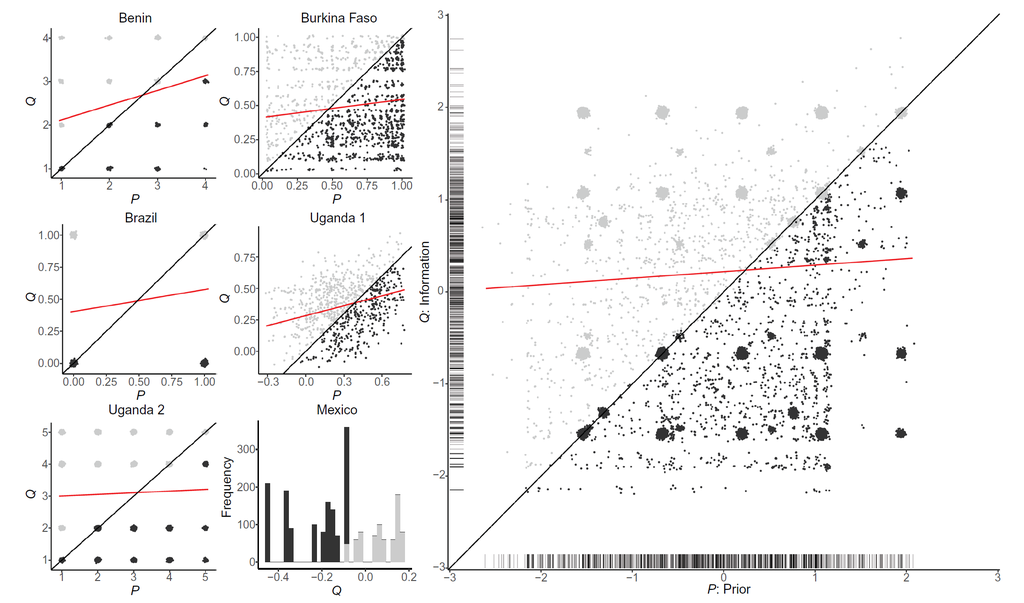

## Problems hindering accumulation

[figure not shown]

## Research Design

**Core hypotheses:**

1. Good news increases voter support for incumbents
2. Bad news decreases voter support for incumbents
3. Effect of information will increase with gap between Q and P
4. Strongest for nonpartisan and non-coethnic voters

## Findings

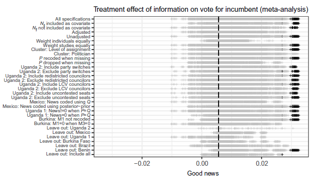

## Why the null results?

- Source credibility?
  - No…
- Lack of retention
- Lack of updating on politician performance
- Lack of updating about politician quality
- Lack of coordination (private treatment)

## Statistical Power

**Null results were not “foregone conclusion”?**

- 80% power
- Change the vote of 5/100 voters
- Change turnout of 4/100 voters

## Findings

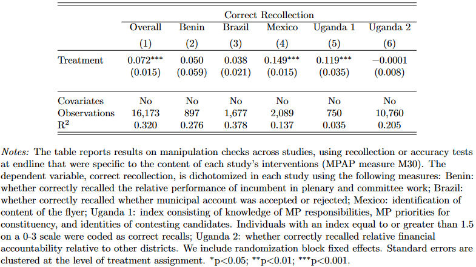

## Findings

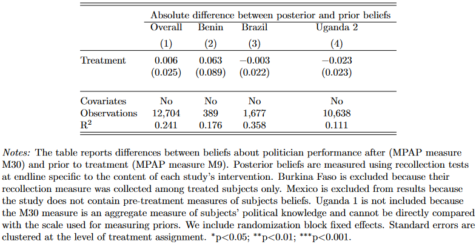

## Findings

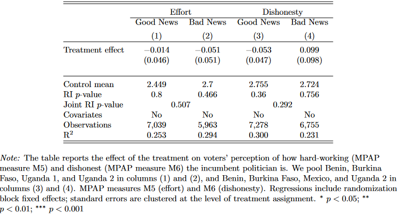

## Policy Implications

- Much of the work funded by donors is probably not having an impact on accountability
- Targeting of information provision needs to be rethought
  - Public dissemination and coordination

# Data Assignment Questions

# Final Project Essentials

## Unit Fixed Effects

**What is a unit fixed effect?**

- Simple linear models make comparisons both across and within units (when there are multiple measures)
- Fixed effects ‘absorb’ variation across units; now coefficients estimate only the variation within units
- This ‘controls’ for time-invariant heterogeneity

**What are they used for?**

- Reducing concerns about confounding
- Difference-in-differences

## Unit Fixed Effects

**Normal model**

$$Y_it = \alpha + \beta_1 X_{it} + \epsilon_{it}$$
**Unit fixed Effects model**

$$Y_it = \gamma_i + \beta_1 X_{it} + \epsilon_{it}$$

**Example:** Unit FEs with one binary predictor

- $\alpha$: $E[Y_i]$ when $X_{i1} = 0$
- $\gamma_i$: $E[Y_i]$ for every unit when $X_{i1} = 0$

## Unit Fixed Effects

**Unit fixed Effects model**

$$Y_it = \gamma_i + \beta_1 X_{it} + \epsilon_{it}$$

- $\gamma_i$: $E[Y_i]$ when $X_{it} = 0$
- $\beta_1$ Change in $E[Y_i]$ when $X_{it} = 1$
- Each $\gamma_i$ will absorb everything that doesn’t vary over time in that unit

## Unit Fixed Effects

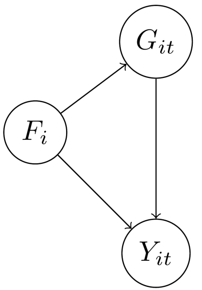

## Unit Fixed Effects

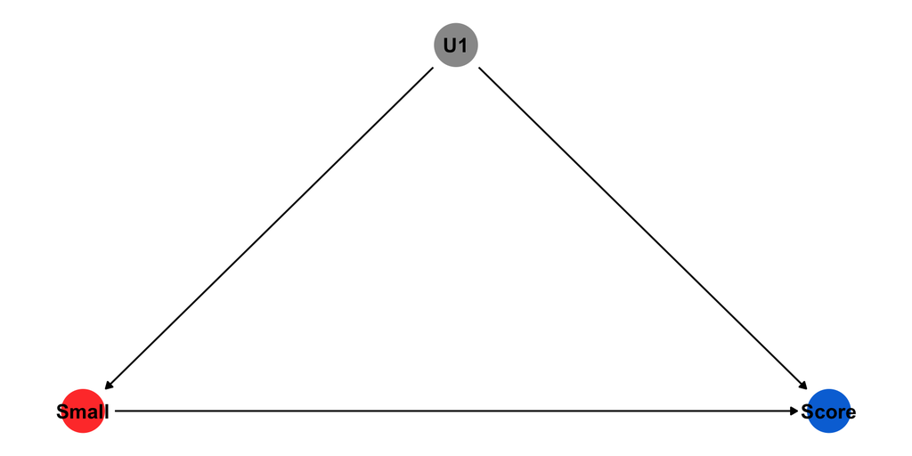

https://carolina-torreblanca.github.io/psci3200-globaldev-main/